# Useing our new function (timestep_deterministic_SIR)

Edie Bishop

13th of November 2019

# Introduction

In this script we call on a new function (timestep_deterministic_SIR), which takes a value for disease transmission rate, a value for recovery rate, and a value for timestep, and returns a dataframe with four columns (susceptibles, infecteds, recovered and time). In this exercise we will be modelling a foot and mouth disease (FMD) outbreak. Since this disease moves so quickly through herds, we will model it in terms of farms affected, rather than individual cattle. The model can be represented mathamatically by the following equation:
$$S(t + 1) = S(t) - \beta * S(t) * I(t) / N$$
$$I(t + 1) = I(t) + \beta * S(t) * I(t) / N - \sigma * I(t)$$
$$R(t + 1) = R(t) + \sigma * I(t)$$
*Where S = susceptible farms, I = infected farms, R = recovered farms, t = time,* *$\beta$ = transmission rate & $\sigma$ = recovery rate*

We will test our new function using two different tansmission rates. The transmission and recovery rates for FMD are generally very high, hence why we are modelling the disease outbreak in farms rather than in individual cattle. For this reason, timesteps need to be small (smaller than 1) in order to properly capture the outbreak.

### Source our functions

We need to source both our new function (timestep_deterministic_SIR), and the plot_populations function.

```r
source("0301_plot_helper.R")
source("0304_step_SIR.R")
```

### Define parameters

To start with we define the population size and the transmission and recovery rates, in this case for FMD infection across farms.

```r
num.farms <- 100
initial.infected <- 2
initial.susceptible <- num.farms - initial.infected
initial.recovered <- num.farms - initial.infected - initial.susceptible
```

Then we define the transmission rate and the recovery rate for FMD.

```r
FMD.transmission.a <- 2
FMD.transmission.b <- 1
FMD.recovery <- 1/2
```

Then we define the start time and the end time for our study, and the timesteps that we wish our model to run over.

```r
start.time <- 0
end.time <- 30
timestep <- 1/7
```

```r
farm.df.1 <- data.frame(SUSCEPTIBLES = initial.susceptible,
                        INFECTED = initial.infected,
                        RECOVERED = initial.recovered,
                        time = start.time)
farm.df.2 <- data.frame(SUSCEPTIBLES = initial.susceptible,
                        INFECTED = initial.infected,
                        RECOVERED = initial.recovered,
                        time = start.time)
```

### Run the function

Now we can run our new timestep_deterministic_SIR. This function will update time and the number of infected, susceptible and recovered farms.

```r
# we define a new dataframe which will be passed through the function
updated.population <- farm.df.1
# Rather than specifying timesteps, we can now use a while() loop to specify that we wish to continue running
# the function until we reach the end time.
while(updated.population$time < end.time)
{updated.population <-
  # our new function accepts four arguments, which we define below
  timestep_deterministic_SIR(latest = tail(farm.df.1, 1),
                             timestep = timestep,
                             transmission.rate = FMD.transmission.a,
                             recovery.rate = FMD.recovery)
# we then update the herd.1 dataframe by adding the updated population dataframe, which has been passed
# through the function, to it.
farm.df.1 <- rbind(farm.df.1, updated.population)
}
```

```r
# We will now do the same again, this time using timestep.b
updated.population <- farm.df.2
while(updated.population$time < end.time)
{updated.population <-
  timestep_deterministic_SIR(latest = tail(farm.df.2, 1),
                             timestep = timestep,
                             transmission.rate = FMD.transmission.b,
                             recovery.rate = FMD.recovery)
farm.df.2 <- rbind(farm.df.2, updated.population)
}
```

### Plot the results

We can now plot the results produced by the timestep_deterministic_SIR function. We would expect that the outbreak with the lower transmission rate will have a slightly more prolonged timeframe, and a lower peak in infected population.

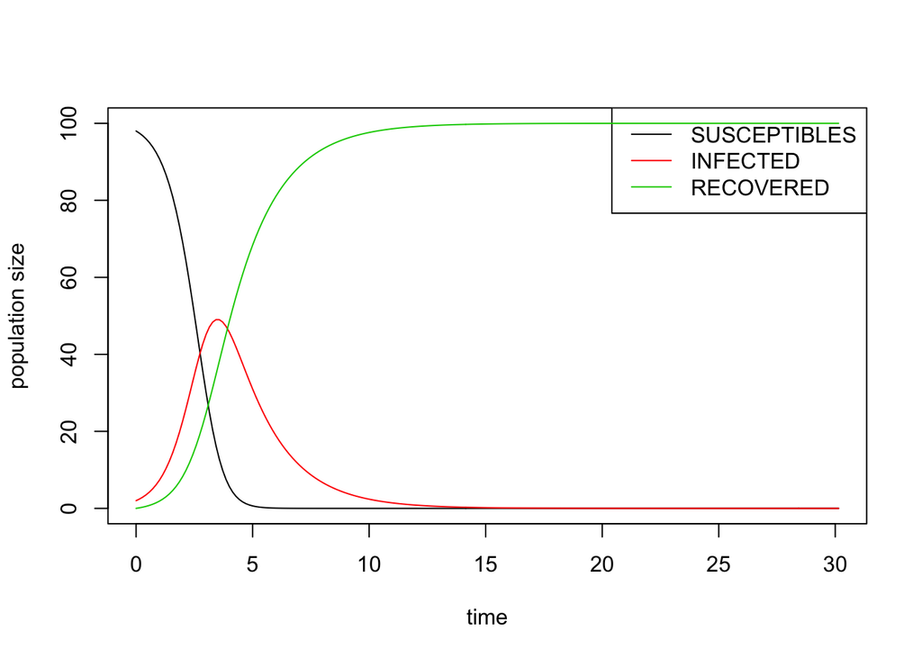

```r
plot_populations(farm.df.1)
```

**Fig 1.** Change in the number of susceptible, infected and recovered farms during a bovine FMD outbreak, assuming an Ro of 4 (transmission rate = 2, recovery rate = 1/2).

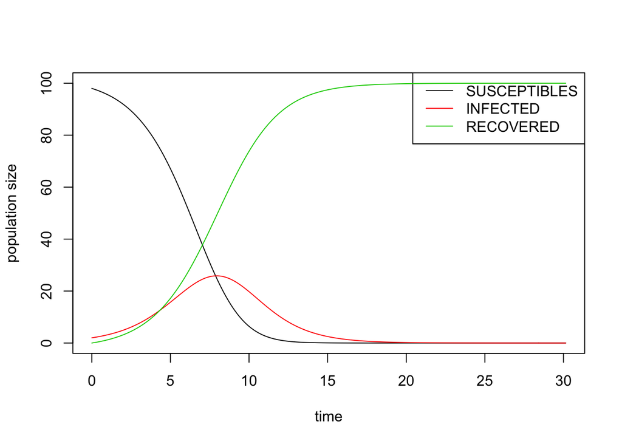

```r
plot_populations(farm.df.2)
```

**Fig 1.** Change in the number of susceptible, infected and recovered farms during a bovine FMD outbreak, assuming an Ro of 2 (transmission rate = 1, recovery rate = 1/2).

## Conclusion

As expected, in the lower transmission rate situation we see that the outbreak results in a lower peak value for the total number of infected farms, and a longer timeframe over which the outbreak occurs. In contrast to the previous examples modelling E. coli outbreaks, where the transmission rate had an effect on the number of susceptible and infected individuals at equilibrium, in this case, since recovery from infection provides immunity against subsequent infection, we see a lower peak number of infected farms, and the peak occuring at a later timepoint with the lower transmission rate, followed by a population consisting entirely of resistant herds in both cases.